# Концепция семафора и ее использование для синхронизации процессов

Презентация доклада

Серебрякова Дарья Ильинична

Российский университет дружбы народов, Москва, Россия

07 марта 2025

# Информация

## Докладчик

- Серебрякова Дарья Ильинична
- студентка 1 курса, бакалавриат, ФФМиЕН
- кондитер, вязальщица, бизнес вумэн
- Российский университет дружбы народов
- dashok1902@icloud.com
- https://github.com/dserebryakova

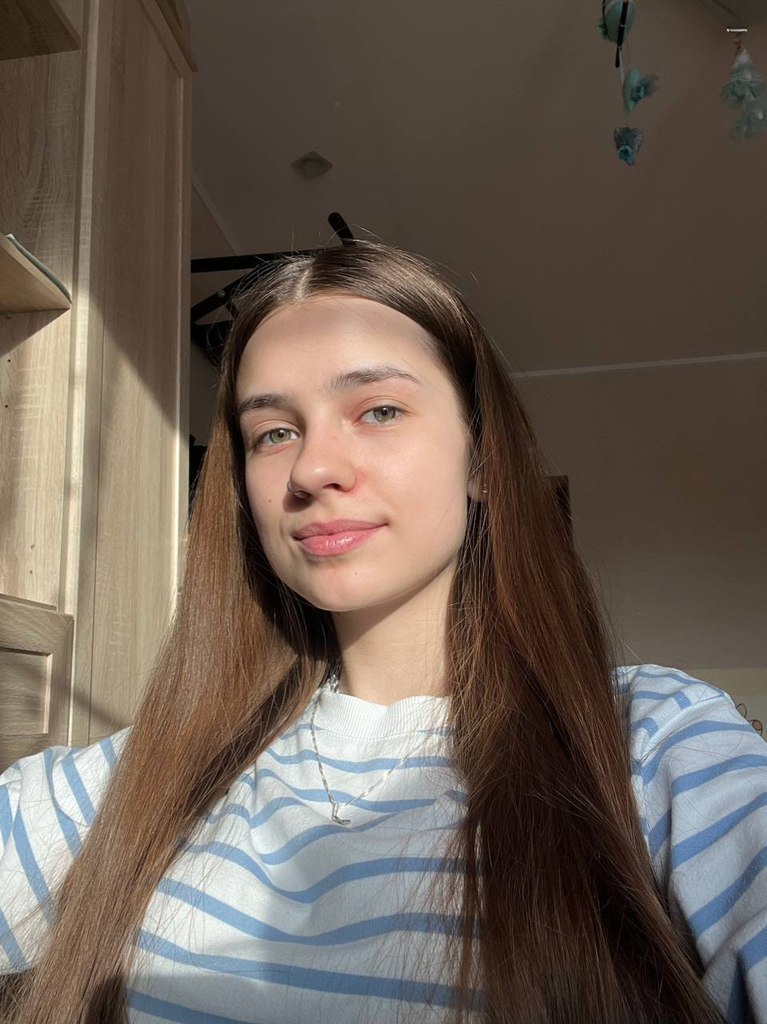

# Вводная часть

## Актуальность

В условиях стремительного развития технологий многопоточности и распределённых систем актуальность исследования концепции семафора становится всё более важной. Современные программные приложения, работающие в многопользовательских средах, требуют эффективных методов синхронизации для предотвращения конфликтов и обеспечения безопасного доступа к разделяемым ресурсам. Семафоры, как один из основных инструментов управления параллелизмом, играют ключевую роль в обеспечении целостности данных и стабильности системы

## Объект и предмет исследования

Объектом исследования являются механизмы синхронизации в многопоточных и многопроцессных вычислительных системах, в частности, способы использования семафоров для организации безопасного взаимодействия между процессами и потоками

Предметом исследования выступает концепция семафора, её типы (счётный и бинарный), принципы работы, алгоритмы реализации и способы применения в различных сценариях многопоточной и многопроцессной обработки данных

## Научная новизна

Научная новизна работы заключается в систематизации и анализе существующих подходов к использованию семафоров. В работе рассматриваются недостатки и достоинства использования семафоров

## Практическая значимость работы

Практическая значимость работы заключается в получении знаний по новой теме

## Цели

- Узнать, что такое семафор
- Узнать, где и как применяется семафор для синхронизации процессов

# Перейдем к семафору

## Эдсгер Дейкстрой

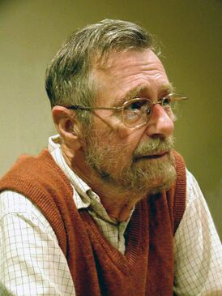

Эдсгер Дейкстрой

(рис. 1)

## Что такое семафор?

Семафор — это синхронизирующий объект, который используется в многопоточных и многопроцессных системах для управления доступом к общим ресурсам

Он помогает избежать проблем, связанных с одновременной работой нескольких процессов с одинаковыми ресурсами

## Виды семафоров

1. Бинарный семафор
- может принимать значения 0 и 1. В некотором смысле такой семафор похож на очередь длины 1
- используется для синхронизации между задачами или для синхронизации между задачей и ее прерыванием
2. Счетный семафор
- может принимать не только значения равные 0 и 1, поэтому он эквивалентен очереди с длиной больше 1 элемента
- используется для событий счета

## Классические задачи синхронизации с использованием концепции семафоров

1. Проблема производителя и потребителя
2. Управление светофором
3. Проблема читателя и писателя

## Использование семафоров

1. Взаимное исключение
2. Синхронизация процессов
3. Управление ресурсами
4. Проблема «читатель-писатель»
5. Предотвращение взаимоблокировок

## Заключение

Семафоры можно использовать для решения классических проблем синхронизации в вычислениях. Они играют важную роль в управлении доступом к общим ресурсам и координации действий параллельных процессов. Они также помогают повысить производительность системы, сохранить целостность данных и устранить конфликты между процессами